- Create a scatter plot for the variables `cty` (x-axis) and `hwy` (y-axis) from the `mpg` dataset.
- Add a geom to show the linear regression between x and y.
  - Use a linear model (`lm`) instead of the default (`loess`) for computing the regression.
  - Set the line color to `red`.
  - Color the points by `class`.
  - Set the point size to 6.

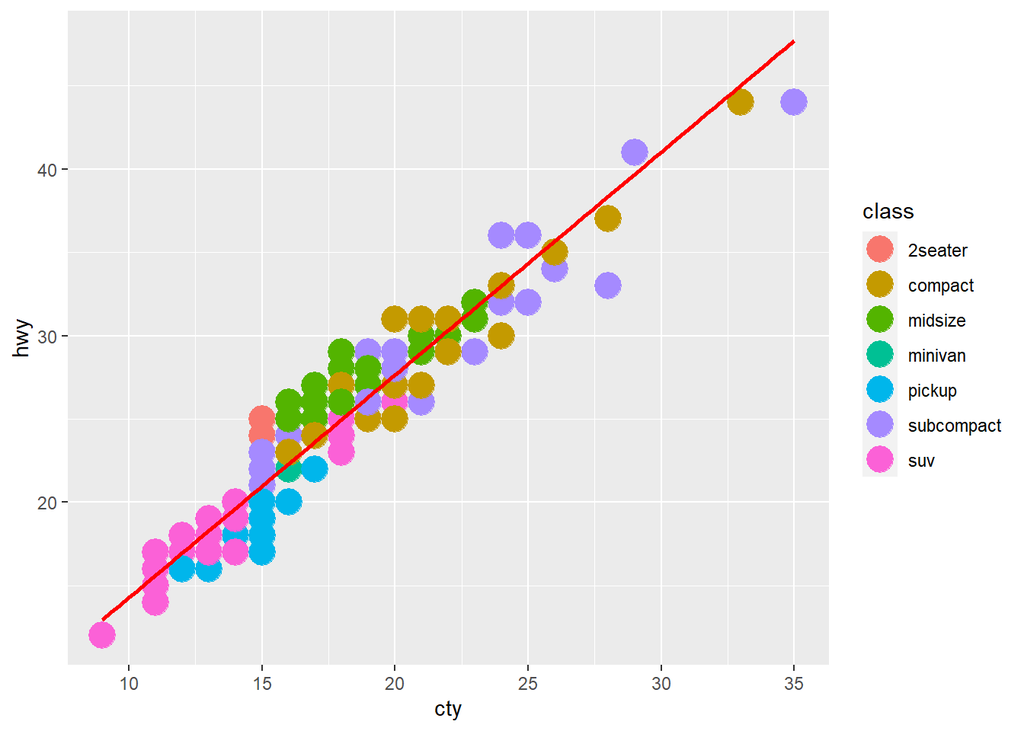

```r
ggplot(data = mpg, aes(x = cty, y = hwy, color = class)) +
  geom_point(size = 6) +
  geom_smooth(method = "lm", se = FALSE, color = "red")
```

**Question 5**

- In the previous plot, you noticed subcompacts with a city fuel consumption of 15 miles per gallon.
- Extract only the manufacturer and model of these subcompacts.

```r
subcompact_15 <- subset (mpg, class == "subcompact" & cty == 15)
subcompact_15
```

```
## # A tibble: 4 × 11
##   manufacturer model   displ  year   cyl trans     drv     cty   hwy fl    class
##   <chr>        <chr>   <dbl> <int> <int> <chr>     <chr> <int> <int> <chr> <chr>
## 1 ford         mustang   4.6  1999     8 auto(l4)  r        15    21 r     subc…
## 2 ford         mustang   4.6  1999     8 manual(m… r        15    22 r     subc…
## 3 ford         mustang   4.6  2008     8 manual(m… r        15    23 r     subc…
## 4 ford         mustang   4.6  2008     8 auto(l5)  r        15    22 r     subc…
```

```r
man_mod_15 <- subcompact_15 [, c("manufacturer","model") ]
man_mod_15
```

```
## # A tibble: 4 × 2
##   manufacturer model
##   <chr>        <chr>
## 1 ford         mustang
## 2 ford         mustang
## 3 ford         mustang
## 4 ford         mustang
```

**Question 6**

- The following code generates a warning:

  ```r
  ggplot(data = mpg) +
    geom_point(mapping = aes(x = displ, y = hwy, shape = class))
  ```

- Correct the code so all classes are displayed.
  - Hint: You can manually specify shapes using the `scale_shape_manual` geom.

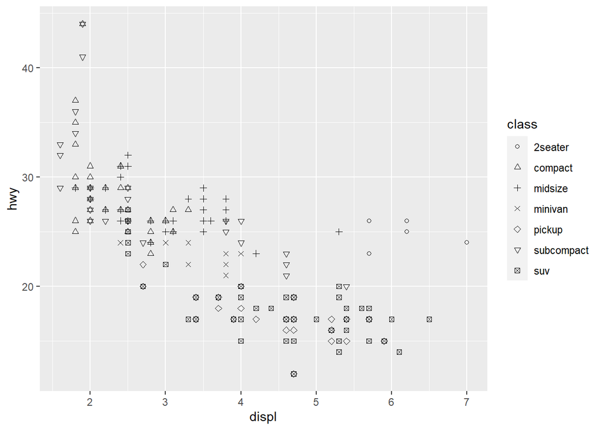

```r
ggplot(data = mpg) +
  geom_point(mapping = aes(x = displ, y = hwy, shape = class)) +
  scale_shape_manual(values = 1:7)
```

**Question 7**

- Given the following two vectors:

```r
x <- c(3.385,0.48,1.35,465,36.33,27.66,14.83,1.04,4.19,0.425,0.101,0.92,1,0.005,0.06,3.5,2,1.7,2547,0.023,187.1,521,0.785,10,3.3,0.2,1.41,529,207,85,0.75,62,6654,3.5,6.8,35,4.05,0.12,0.023,0.01,1.4,250,2.5,55.5,100,52.16,10.55,0.55,60,3.6,4.288,0.28,0.075,0.122,0.048,192,3,160,0.9,1.62,0.104,4.235)
y <- c(44.5,15.5,8.1,423,119.5,115,98.2,5.5,58,6.4,4,5.7,6.6,0.14,1,10.8,12.3,6.3,4603,0.3,419,655,3.5,115,25.6,5,17.5,680,406,325,12.3,1320,5712,3.9,179,56,17,1,0.4,0.25,12.5,490,12.1,175,157,440,179.5,2.4,81,21,39.2,1.9,1.2,3,0.33,180,25,169,2.6,11.4,2.5,50.4)
```

- Combine the two vectors into a data frame called `sizeMass`.
  - Name the columns as `size` and `mass` respectively.

```r
x <- c(3.385,0.48,1.35,465,36.33,27.66,14.83,1.04,4.19,0.425,0.101,0.92,1,0.005,0.06,3.5,2,1.7,2547,0.023,187.1,521,0.785,10,3.3,0.2,1.41,529,207,85,0.75,62,6654,3.5,6.8,35,4.05,0.12,0.023,0.01,1.4,250,2.5,55.5,100,52.16,10.55,0.55,60,3.6,4.288,0.28,0.075,0.122,0.048,192,3,160,0.9,1.62,0.104,4.235)
y <- c(44.5,15.5,8.1,423,119.5,115,98.2,5.5,58,6.4,4,5.7,6.6,0.14,1,10.8,12.3,6.3,4603,0.3,419,655,3.5,115,25.6,5,17.5,680,406,325,12.3,1320,5712,3.9,179,56,17,1,0.4,0.25,12.5,490,12.1,175,157,440,179.5,2.4,81,21,39.2,1.9,1.2,3,0.33,180,25,169,2.6,11.4,2.5,50.4)
size_mass <- data.frame (size = x, mass = y)
size_mass
```

```
##        size    mass
## 1     3.385   44.50
## 2     0.480   15.50
## 3     1.350    8.10
## 4   465.000  423.00
## 5    36.330  119.50
## 6    27.660  115.00
## 7    14.830   98.20
## 8     1.040    5.50
## 9     4.190   58.00
## 10    0.425    6.40
## 11    0.101    4.00
## 12    0.920    5.70
## 13    1.000    6.60
## 14    0.005    0.14
```

[output cut: 48 more lines]

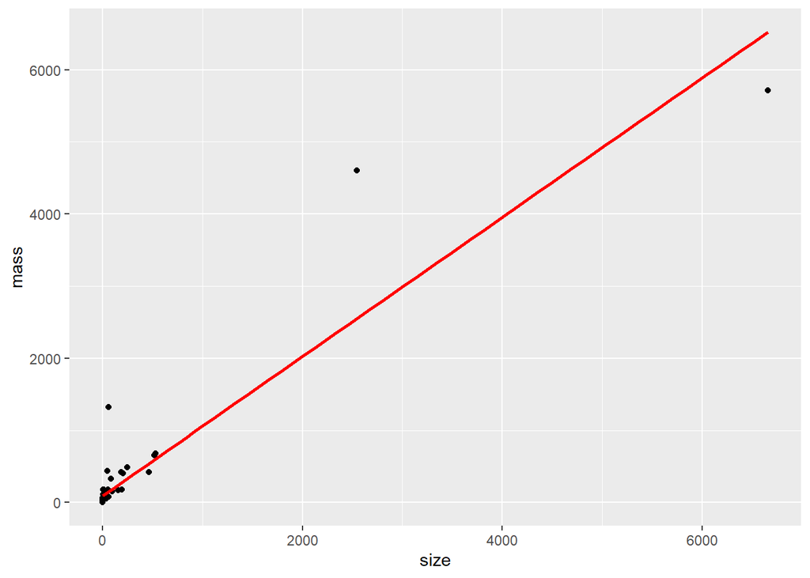

```r
ggplot(size_mass, aes(size, mass)) +
      geom_point() +
      geom_smooth(method = "lm", color = "red", se = FALSE)
```

- Use the code below to plot the data.

  ```r
  ggplot(sizeMass, aes(size, mass)) +
    geom_point() +
    geom_smooth(method = "lm", color = "red", se = FALSE)
  ```

**Question 8**

- Transform the data in the plot to mitigate the “squashed” appearance.
1. Add two new columns named `size_log10` and `mass_log10` containing the log10 values of `size` and `mass`, respectively. Then use these new columns for plotting.

```r
library(dplyr)
size_mass <- size_mass %>%
  mutate(size_log10 = log10 (size),
         mass_log10 = log10 (mass))
size_mass
```

```
##        size    mass  size_log10  mass_log10
## 1     3.385   44.50  0.52955867  1.64836001
## 2     0.480   15.50 -0.31875876  1.19033170
## 3     1.350    8.10  0.13033377  0.90848502
## 4   465.000  423.00  2.66745295  2.62634037
## 5    36.330  119.50  1.56026540  2.07736791
## 6    27.660  115.00  1.44185218  2.06069784
## 7    14.830   98.20  1.17114115  1.99211149
## 8     1.040    5.50  0.01703334  0.74036269
## 9     4.190   58.00  0.62221402  1.76342799
## 10    0.425    6.40 -0.37161107  0.80617997
## 11    0.101    4.00 -0.99567863  0.60205999
## 12    0.920    5.70 -0.03621217  0.75587486
## 13    1.000    6.60  0.00000000  0.81954394
## 14    0.005    0.14 -2.30103000 -0.85387196
```

[output cut: 48 more lines]

2. Use `scale_x_log10()` and `scale_y_log10()` to set different scales for the x and y aesthetics.

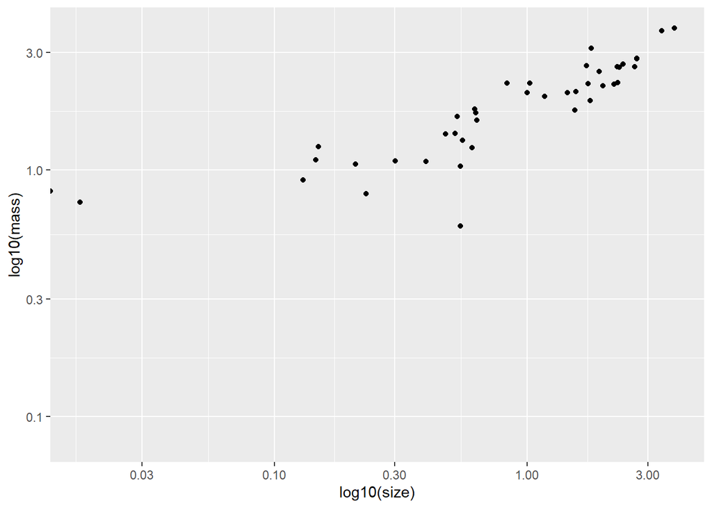

```r
ggplot(size_mass, aes(x = size_log10, y = mass_log10)) +
  geom_point() +
  scale_x_log10() +
  scale_y_log10() +
  labs(x = "log10(size)", y = "log10(mass)")
```